# Plum Island Marsh LTER; Diversity Cascades

12/18/2020

## Plum Island LTER

PIE LTER is a long term ecological research network involving PIs and students from a range of Universities. Their mission is to understand marsh ecosystems, the land-sea interface, and involve government and non-government organizations in outreach & understanding current or future anthropogenic impact on these environments.

My interests were directed towards thoughts about marsh diversity in the **Tide Project**.

[figure not shown]

## The Tide Project

- *A unique approach* at scaling experimental ecology and studying **true** effects (mesocosm).
  - The entire ecosystem, inclusive of known knowns, known unknowns, and unknown unknowns is present and active.
- *Addressing issues of global-change biology* by studying abiotic and geochemical shifts on a larger scale.
  - Effects on the nitrogen, carbon, or sulfur cycles are more accurately understood.
- *An emphasis on undergraduate and young scientist involvement* to bring in more young investigators.
  - Easy to approach front of ideas with hands on experiential gains to be had.

## Data of interest

- Two datasets pertaining to the Clubhead, Sweeney, Nelson, and West creeks; the first two being fertilized sites recieving nitrogen rich runoff, and the latter two being control sites.
- One of these datasets describes acroinfaunal counts of species in the creeks, and the other describes nekton counts in the creeks; their common factors to join by being month, year, creek, and branch of the creek.
- This involved some pretty in depth usage of **tidyr**, **dplyr**, **readr**, **janitor**, **lubridate**, and **vegan**.
  - The data was really good but months were and years were recorded with different systems that were not datetime compliant and had to be extracted and modified to join on.
  - Counts for nekton was wide data instead of long data and had to be summarized from grids to a branch, cleaned, and then pivoted to long data.

## Spaghetti Code

[figure not shown]

## Preliminary Visualization

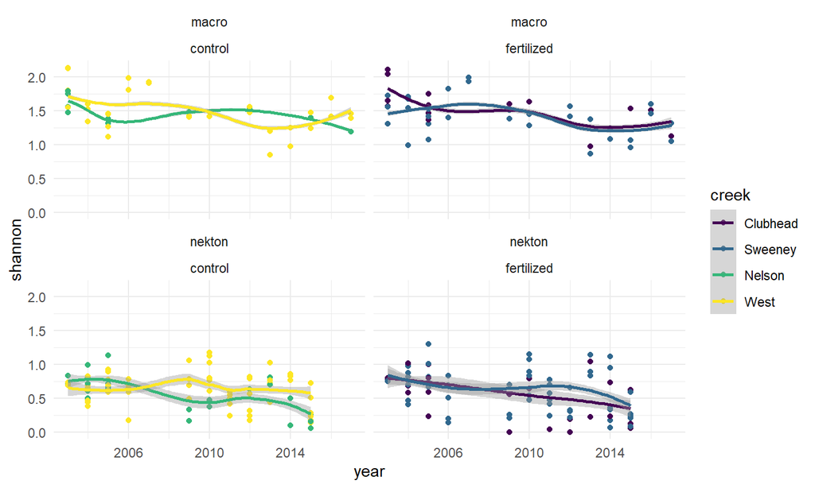

## What is up in the Nekton Club

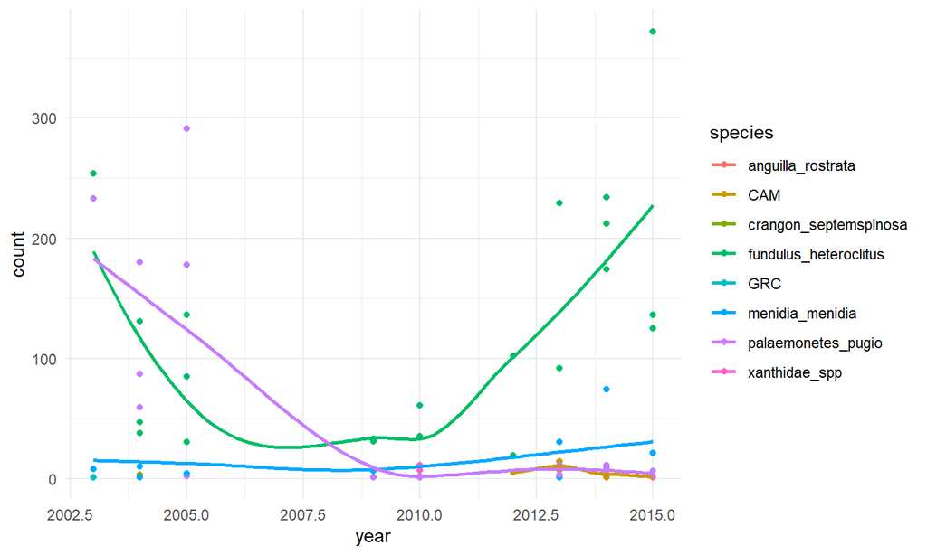

## Inspecting Nekton & Macro Club

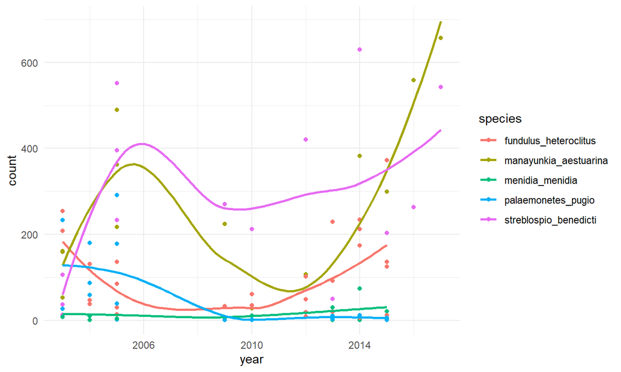

## Inspecting Nekton & Macro Sweeney

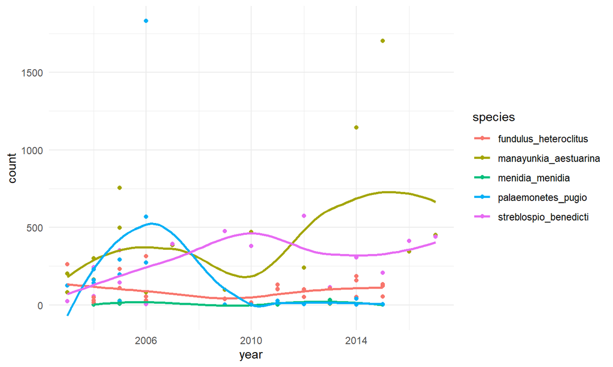

## Nekton & Macro effects

```
## type = macro:
##  contrast        estimate      SE  df z.ratio p.value
##  Clubhead effect   0.0719 0.00848 Inf   8.473 <.0001
##  Sweeney effect   -0.0703 0.00693 Inf -10.144 <.0001
##  Nelson effect    -0.0249 0.00926 Inf  -2.692 0.0071
##  West effect       0.0234 0.00693 Inf   3.372 0.0010
##
## type = nekton:
##  contrast        estimate      SE  df z.ratio p.value
##  Clubhead effect  -0.0169 0.01770 Inf  -0.955 0.4529
##  Sweeney effect    0.0141 0.01361 Inf   1.039 0.4529
##  Nelson effect    -0.0119 0.01806 Inf  -0.658 0.5105
##  West effect       0.0146 0.01338 Inf   1.095 0.4529
##
## P value adjustment: fdr method for 4 tests
```

- Fertilized creeks are clearly outliers from very similar controls
- Nekton effect is not obvious in data, look at species

## Nekton & Macro assumption

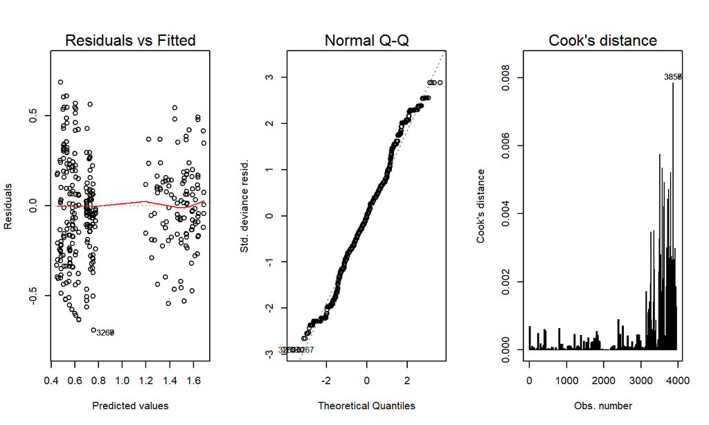

Resids, qqplot, and cooks d are all in normal assumption range.

## Nekton Species Effect

```
## species = anguilla_rostrata:
##  contrast        estimate     SE  df z.ratio p.value
##  Clubhead effect   0.0761  0.600 Inf  0.127  0.8991
##  Sweeney effect    0.1388  0.400 Inf  0.347  0.8991
##  Nelson effect    -0.3404  0.545 Inf -0.625  0.8991
##  West effect       0.1255  0.426 Inf  0.295  0.8991
##
## species = crangon_septemspinosa:
##  contrast        estimate     SE  df z.ratio p.value
##  Clubhead effect  -0.6615  1.648 Inf -0.401  0.8335
##  Sweeney effect   -0.1954  0.930 Inf -0.210  0.8335
##  Nelson effect    -1.7466  0.891 Inf -1.960  0.1022
##  West effect       2.6035  1.335 Inf  1.951  0.1022
##
## species = fundulus_heteroclitus:
##  contrast        estimate     SE  df z.ratio p.value
##  Clubhead effect   0.0817 14.874 Inf  0.005  0.9956
##  Sweeney effect  -19.6119 11.972 Inf -1.638  0.2028
##  Nelson effect    -4.1953 14.863 Inf -0.282  0.9956
##  West effect      23.7256 13.691 Inf  1.733  0.2028
##
## species = menidia_menidia:
##  contrast        estimate     SE  df z.ratio p.value
##  Clubhead effect   5.7913  3.717 Inf  1.558  0.2385
##  Sweeney effect   -3.3724  1.996 Inf -1.690  0.2385
##  Nelson effect    -0.9226  2.589 Inf -0.356  0.7215
##  West effect      -1.4964  2.000 Inf -0.748  0.6058
##
## species = palaemonetes_pugio:
##  contrast        estimate     SE  df z.ratio p.value
##  Clubhead effect -26.2715 14.310 Inf -1.836  0.1327
##  Sweeney effect    7.1158 13.418 Inf  0.530  0.5959
##  Nelson effect   -18.1803 14.592 Inf -1.246  0.2837
##  West effect      37.3359 14.623 Inf  2.553  0.0427
##
## species = pungitius_pungitius:
##  contrast        estimate     SE  df z.ratio p.value
##  Clubhead effect  -6.2589  1.953 Inf -3.204  0.0054
##  Sweeney effect   12.9731  4.764 Inf  2.723  0.0129
##  Nelson effect    -1.9433  2.660 Inf -0.731  0.4651
##  West effect      -4.7709  1.881 Inf -2.536  0.0149
##
## species = xanthidae_spp:
##  contrast        estimate     SE  df z.ratio p.value
##  Clubhead effect   2.8934  3.221 Inf  0.898  0.6417
##  Sweeney effect   -0.8560  1.840 Inf -0.465  0.6417
##  Nelson effect    -1.0704  1.948 Inf -0.550  0.6417
##  West effect      -0.9670  1.715 Inf -0.564  0.6417
##
## P value adjustment: fdr method for 4 tests
```

## Nekton Species assumption

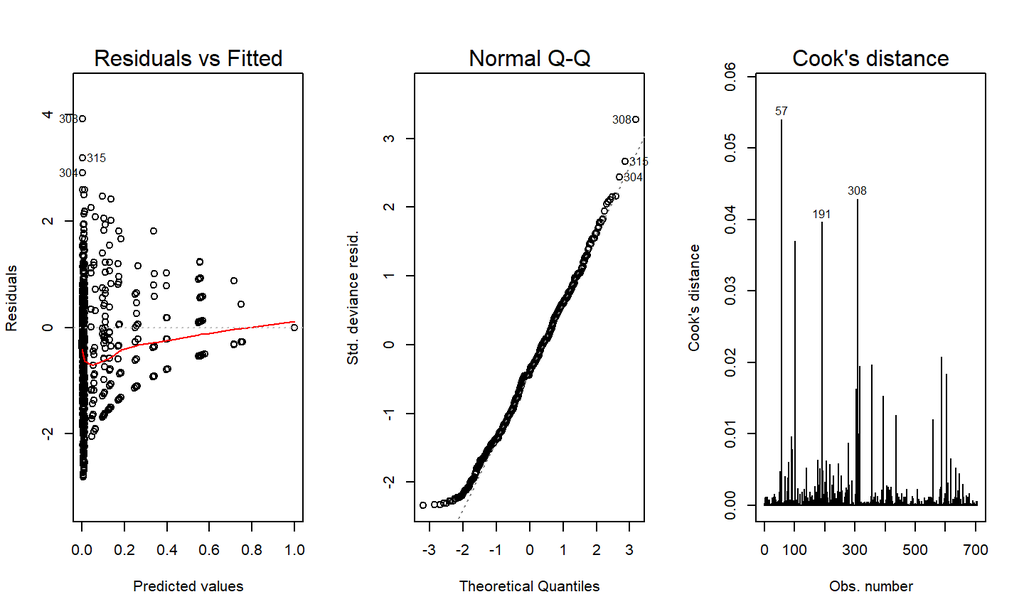

## Bad data?

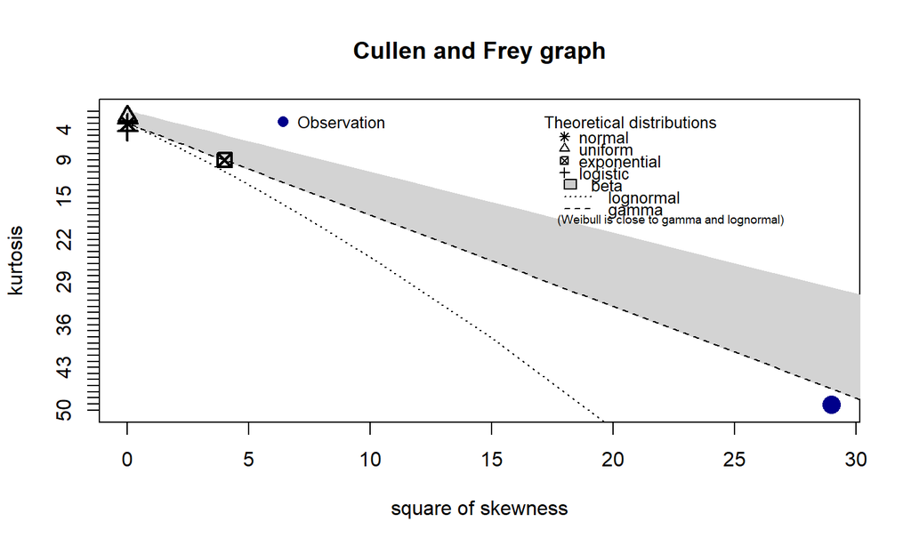

```
## summary statistics
## ------
## min:  1   max:  1832
## median:  17
## mean:  86.24646
## estimated sd:  161.5193
## estimated skewness:  5.385021
## estimated kurtosis:  49.09816
```